# MANOVA and A Cool Thing Called PERMANOVA

## Matrix Formulation

The above helps sketch the logic of MANOVA, but rather than these sum-of-squares calculations, in practice matricies are used to compute the test statistic. These matricies are known as Sum-of-Squares-and-Cross-Products (SSCP) matricies. The sum of their diagonal elements (i.e., the trace of the matrix) gives you the sum-of-squares values we just obtained.

How do we calculate them? Each individual subject has a response vector containing their values for each of the response variables. You can subtract the mean of each response variable from each value. Then you take the outer product of each person’s centered response vector with itself, resulting in a $p \times p$ matrix for each person, where $p$ is the number of response variables. Just add these up across every person to get the total SSCP matrix. Recall that the outer product of a vector with itself is symmetric and calculated, for some matrix $Z$, as follows:

In this context, each person $i$ has their own outer-product matrix, and we add them up to get the total

You get one of these for each person $i$. Summing up across all people $i$ (and groups $j$),

$$\mathbf{T}=\sum_i \sum_j \begin{bmatrix}y_{1ij}-\bar y_{1\cdot \cdot}\\ y_{2ij}-\bar y_{2\cdot \cdot} \end{bmatrix}\begin{bmatrix}y_{1ij}-\bar y_{1\cdot \cdot}\\ y_{2ij}-\bar y_{2\cdot \cdot}\end{bmatrix}'$$

Here’s a way to calculate this by hand in R:

```r
Y<-cbind(mtcars$hp,mtcars$mpg)
head(Y)
```

```
##      [,1] [,2]
## [1,]  110 21.0
## [2,]  110 21.0
## [3,]   93 22.8
## [4,]  110 21.4
## [5,]  175 18.7
## [6,]  105 18.1
```

```r
Ycent<-cbind(Y[,1]-as.matrix(grandmean[1]),Y[,2]-as.matrix(grandmean[2]))
head(Ycent)
```

```
##          [,1]      [,2]
## [1,] -36.6875  0.909375
## [2,] -36.6875  0.909375
## [3,] -53.6875  2.709375
## [4,] -36.6875  1.309375
## [5,]  28.3125 -1.390625
## [6,] -41.6875 -1.990625
```

```r
Ycent[1,]%*%t(Ycent[1,])
```

```
##           [,1]        [,2]
## [1,] 1345.9727 -33.3626953
## [2,]  -33.3627   0.8269629
```

```r
Tmat<-matrix(c(0,0,0,0),nrow=2)

for(i in 1:32){
Tmat<-Tmat+Ycent[i,]%*%t(Ycent[i,])
}

Tmat
```

```
##            [,1]      [,2]
## [1,] 145726.875 -9942.694
## [2,]  -9942.694  1126.047
```

```r
sum(diag(Tmat))
```

```
## [1] 146852.9
```

Notice that the diagonal elements of `Tmat` sum to SST. Furthermore, just like SST, this matrix can be partitioned into a part due to differences between groups and a part due to error. Traditionally, the part due to differences between groups (analogous to the SSB) is called the hypothesis matrix H, while the part due to error (analogous to the SSW) is called the error matrix E.

We can calculate them using a procedure similar to the one used above. For the SSE, we do the exact same thing except we center each person’s response vector using the *group* mean ($\bar y_{1\cdot j}$) rather than the grand mean ($\bar y_{1\cdot \cdot}$)

$\mathbf{E}=\sum_i \sum_j \begin{bmatrix}y_{1ij}-\bar y_{1\cdot j}\\ y_{2ij}-\bar y_{2\cdot j} \end{bmatrix}\begin{bmatrix}y_{1ij}-\bar y_{1\cdot j}\\ y_{2ij}-\bar y_{2\cdot j}\end{bmatrix}'$

```r
groupmeans<-mtcars%>%group_by(am)%>%mutate(meanhp=mean(hp), meanmpg=mean(mpg))%>%ungroup()%>%select(meanhp,meanmpg)

Ycent<-cbind(Y[,1]-as.matrix(groupmeans[,1]),Y[,2]-as.matrix(groupmeans[,2]))
head(Ycent)
```

```
##         meanhp    meanmpg
## [1,] -16.84615 -3.3923077
## [2,] -16.84615 -3.3923077
## [3,] -33.84615 -1.5923077
## [4,] -50.26316  4.2526316
## [5,]  14.73684  1.5526316
## [6,] -55.26316  0.9526316
```

```r
Ycent[1,]%*%t(Ycent[1,])
```

```
##         meanhp  meanmpg
## [1,] 283.79290 57.14734
## [2,]  57.14734 11.50775
```

```r
Emat<-matrix(c(0,0,0,0),nrow=2)
for(i in 1:32){
Emat<-Emat+Ycent[i,]%*%t(Ycent[i,])
}

Emat
```

```
##          meanhp    meanmpg
## [1,] 137107.377 -8073.9522
## [2,]  -8073.952   720.8966
```

```r
sum(diag(Emat))
```

```
## [1] 137828.3
```

For the hypothesis matrix, it’s easier still. We need only to take the outer product of the vector containing the difference between the group mean and the grand mean for each variable and weight each entry by the number of people in that group. Since there are only two groups, we only have to add two matricies!

$$\mathbf{E}=\sum_j n_j \begin{bmatrix}\bar y_{1\cdot \cdot}-\bar y_{1\cdot j}\\ \bar y_{2\cdot \cdot}-\bar y_{2\cdot j} \end{bmatrix}\begin{bmatrix}\bar y_{1\cdot \cdot}-\bar y_{1\cdot j}\\ \bar y_{2\cdot \cdot}-\bar y_{2\cdot j}\end{bmatrix}'$$

```r
Ycent<-unique(groupmeans)-rbind(grandmean,grandmean)
Ycent<-as.matrix(Ycent)
Ycent
```

```
##         meanhp   meanmpg
## [1,] -19.84135  4.301683
## [2,]  13.57566 -2.943257
```

```r
#how many in each transmission group?
table(mtcars$am)
```

```
##
##  0  1
## 19 13
```

```r
Hmat <-13*Ycent[1,]%*%t(Ycent[1,]) + 19*Ycent[2,]%*%t(Ycent[2,])
Hmat
```

```
##         meanhp    meanmpg
## [1,]  8619.498 -1868.7415
## [2,] -1868.742   405.1506
```

Notice first that $T=E+H$

```r
Tmat
```

```
##            [,1]      [,2]
## [1,] 145726.875 -9942.694
## [2,]  -9942.694  1126.047
```

```r
Emat+Hmat
```

```
##          meanhp   meanmpg
## [1,] 145726.875 -9942.694
## [2,]  -9942.694  1126.047
```

We can get these matricies straight from the `manova` commanda in R

```r
summary(manova(cbind(hp,mpg)~am,data=mtcars))$SS
```

```
## $am
##            hp        mpg
## hp   8619.498 -1868.7415
## mpg -1868.742   405.1506
##
## $Residuals
##             hp        mpg
## hp  137107.377 -8073.9522
## mpg  -8073.952   720.8966
```

Also, if you are more comfortable thinking in terms of covariance matricies, you can calculate the SSCPs like this

```r
#Tmat
31*cov(cbind(mtcars$hp,mtcars$mpg))
```

```
##            [,1]      [,2]
## [1,] 145726.875 -9942.694
## [2,]  -9942.694  1126.047
```

```r
#Emat
automatic<-mtcars%>%filter(am=="1")%>%select(hp,mpg)
manual<-mtcars%>%filter(am=="0")%>%select(hp,mpg)

((13-1)*cov(automatic)+(19-1)*cov(manual))
```

```
##             hp        mpg
## hp  137107.377 -8073.9522
## mpg  -8073.952   720.8966
```

## From the SSCP matricies to hypothesis tests

So we’ve got these matricies: now what? We use them to calculate test statistics! Recall that in a univariate ANOVA, an F-statistic is a ratio of the variation between groups to the variation within groups, and thus that ratio is close to 1 when those quantities are similar. Analogously, since $\mathbf{H}$ represents the variation between groups and $\mathbf{E}$ represents the variation within groups, then if they are very simliar we would expect $\mathbf{H}\mathbf{E}^{-1}]\approx\mathbf{I}$, where $\mathbf{I}$ is the identity matrix (ones along the diagonal, zeros elsewhere). The extent to which the diagonal elements of this matrix differ from ones indicate some difference in outcome variation between groups compared to that within groups, but how are we to distill that down into a test statistic?

There are four common test statistics, each of which is representable as a pseudo-F statistic. They all yield roughly the same pseudo-F.

#### Wilks Lambda

Wilks lambda is a common test statistic. It is calculated using the determinant of the $\mathbf{E}$ matrix divided by the determinant of the $\mathbf{T}$ matrix (recall that $\mathbf{T}=\mathbf{H}+\mathbf{E}$) $\Lambda=\frac{|\mathbf{E}|}{|\mathbf{T}|}$. Recall that a determinant of a two-by-two matrix $\begin{bmatrix}a & b \\ c & d \end{bmatrix}$ is just $ad-bc$ or the difference between the product of the main diagonal and of off-diagonal.

If $\mathbf{E}$ is large relative to $\mathbf{T}$, then Wilks lambda will be large (thus, you reject the null hypothesis when $\Lambda$ is close to zero).

```r
det(Emat)/det(Tmat)
```

```
## [1] 0.5158258
```

#### Hotelling-Lawley

This one is a little different. Here we multiply the hypothesis matrix $\mathbf{H}$ by the inverse of the error matrix $\mathbf{E}$ (similar to division with scalars), and then take the trace of the resulting matrix (i.e., the sum of the diagonals). Because multiplying by the inverse of a matrix is analogous to dividing by that matrix, if $\mathbf{H}$ is large relative to $\mathbf{E}$, then $T^2_0=trace(\mathbf{\mathbf{HE}^{-1}})$ will be large, and so large values of this statistic reject H0.

```r
sum(diag(Hmat%*%solve(Emat)))
```

```
## [1] 0.9386389
```

Recall that for a $2\times2$ matrix, the inverse of a matrix $\mathbf{X}$ is just the matrix such that $\mathbf{XX^{-1}=}\begin{bmatrix}1 & 0 \\ 0 & 1\end{bmatrix}$

#### Pillai

Another trace-based method, this one simply takes the matrix ratio of $\mathbf{H}$ to $\mathbf{T}$ rather than $\mathbf{H}$ to $\mathbf{E}$: $V=trace(\mathbf{HT^{-1}})$

```r
sum(diag(Hmat%*%solve(Tmat)))
```

```
## [1] 0.4841742
```

#### Roy’s Maximum Root

This final method takes the largest eigenvalue of the $\mathbf{HE}^{-1}$ matrix. Recall that eigenvalues of a matrix $\mathbf{X}$ are solutions $\lambda$ to the equation $\mathbf{Xv}=\lambda\mathbf{v}$. Basically, it means that there is a vector $\mathbf{v}$ and scalars $\lambda$ such that, when $\mathbf{X}$ multiplies $\mathbf{v}$, it will only scale the vector (by $\lambda$ amount) and not rotate it. That equation will only have solutions if $|\mathbf{X}-\lambda \mathbf{I}|=0$, where $\mathbf{I}$ is the identity matrix. And can be used to find $\lambda$ with a bit of algebra.

```r
max(eigen(Hmat%*%solve(Emat))$values)
```

```
## [1] 0.9386389
```

### In R

```r
summary(manova(cbind(hp,mpg)~am,data=mtcars),test="Wilks")
```

```
##           Df   Wilks approx F num Df den Df    Pr(>F)
## am         1 0.51583    13.61      2     29 6.781e-05 ***
## Residuals 30
## ---
## Signif. codes:  0 '***' 0.001 '**' 0.01 '*' 0.05 '.' 0.1 ' ' 1
```

```r
summary(manova(cbind(hp,mpg)~am,data=mtcars),test="Hotelling-Lawley")
```

```
##           Df Hotelling-Lawley approx F num Df den Df    Pr(>F)
## am         1          0.93864    13.61      2     29 6.781e-05 ***
## Residuals 30
## ---
## Signif. codes:  0 '***' 0.001 '**' 0.01 '*' 0.05 '.' 0.1 ' ' 1
```

```r
summary(manova(cbind(hp,mpg)~am,data=mtcars),test="Pillai")
```

```
##           Df  Pillai approx F num Df den Df    Pr(>F)
## am         1 0.48417    13.61      2     29 6.781e-05 ***
## Residuals 30
## ---
## Signif. codes:  0 '***' 0.001 '**' 0.01 '*' 0.05 '.' 0.1 ' ' 1
```

```r
summary(manova(cbind(hp,mpg)~am,data=mtcars),test="Roy")
```

```
##           Df     Roy approx F num Df den Df    Pr(>F)
## am         1 0.93864    13.61      2     29 6.781e-05 ***
## Residuals 30
## ---
## Signif. codes:  0 '***' 0.001 '**' 0.01 '*' 0.05 '.' 0.1 ' ' 1
```

Each of these four statistics can be translated into an F-statistic for convenience (note that here, it’s around 13.61). In this example, they all agree, but they don’t have to. When this happens, Pillai’s trace is the most robust (note that it is the default in R’s `manova` function).

## PERMANOVA

MANOVA is a little restrictive: it makes all of the ANOVA assumptions, and then some! It would be nice not to have to make these assumptions! This would permit us to use the technique on count data (e.g., abundances, percentage cover, frequencies, biomass), which for example would allow us answer many questions in ecology (e.g., do abundances of several bird species differ based on the tree composition of a sampling site?). We could also get around the weird multivariate statistics this way and compute familiar F-ratios. Let me show you what I mean.

We will start off with the distance matrix. This tells you how far each multivariate response is from each other. For example, how far is a single car’s $(hp_1, mpg_1)$ from another car’s $(hp_2, mpg_2)$ in the 2D plane? An easy way is to use the euclidean distance described above, $d=\sqrt{(hp_1-hp_2)^2+(mpg_1-mpg_2)^2}$.

We use the distance matrix to calculate the pseudo F-ratio: the ratio of the variation between centroids to the variation within clusters. Note that this is the same as the ratio of the trace of $\mathbf{H}$ to the trace of $\mathbf{E}$.

```r
euc_dist<-dist(mtcars[,c("hp","mpg")],method="euclid")
euc_dist_auto<-dist(mtcars[mtcars$am=="1",c("hp","mpg")],method="euclid")
euc_dist_manual<-dist(mtcars[mtcars$am=="0",c("hp","mpg")],method="euclid")

SSE<-sum(euc_dist_auto^2)/13+sum(euc_dist_manual^2)/19
SST<-sum(euc_dist^2)/32

Fstat=(SST-SSE)/(SSE/30)
Fstat
```

```
## [1] 1.964325
```

To free ourselves from the assumption of normality, we can do a *permutation test* instead of using the F distribution to do a MANOVA. This technique, known as PERMANOVA, was developed by Marti Anderson of Auckland, NZ: [original paper](https://onlinelibrary.wiley.com/doi/pdf/10.1002/9781118445112.stat07841).

To do a PERMANOVA, we will shuffle our data randomly, re-compute f ratio, and repeat these two steps many times, saving the F each time. This gives us a large set of Fs that arise in a situation where there is no systematic difference between groups. All we have to do is just this null distribution and see how unusually our original F would be! If our actual F statistic is far away from the majority of the F statistics that arise in the simulationed distribution whwere there is no difference between groups, then we have evidence that our response variables differ between those groups!

In the `mtcars` example, we are comparing whether horsepower, milage, or both differ between cars with automatic versus manual transmissions. To generate the null distribution, we just randomly scramble the groups (automatic vs. manual) before we calculate each F statistic. We are literally just making up which `hp, mpg` data go with manual and which go with automatic. Thus, in the long run (after many repetitions), the two groups should have equal Fs on average. See the distribution of Fs after such a process below

```r
set.seed(123)
perm.sampdist<-replicate(5000,{

randcars<-mtcars
randcars$am<-sample(randcars$am)

euc_dist<-dist(randcars[,c("hp","mpg")],method="euclid")
euc_dist_auto<-dist(randcars[randcars$am=="1",c("hp","mpg")],method="euclid")
euc_dist_manual<-dist(randcars[randcars$am=="0",c("hp","mpg")],method="euclid")

SSR<-sum(euc_dist_auto^2)/13+sum(euc_dist_manual^2)/19
SST<-sum(euc_dist^2)/32

(SST-SSR)/(SSR/30)
} )

mean(perm.sampdist>Fstat)
```

```
## [1] 0.1744
```

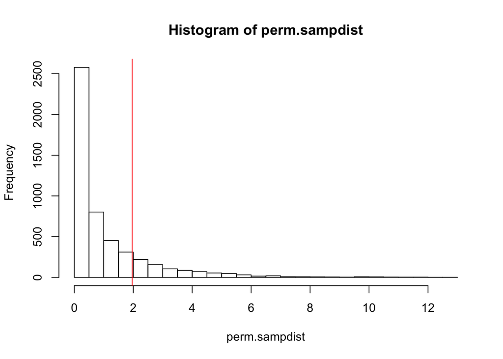

```r
hist(perm.sampdist,breaks=20); abline(v = Fstat,col='red')
```

In the R package `vegan`, there is a built-in function which conducts a permanova on a distance matrix (doesn’t need to be euclidean either)!

```r
library(vegan)
adonis(euc_dist~am,data=mtcars)
```

```
##
## Call:
## adonis(formula = euc_dist ~ am, data = mtcars)
##
## Permutation: free
## Number of permutations: 999
##
## Terms added sequentially (first to last)
##
##           Df SumsOfSqs MeanSqs F.Model      R2 Pr(>F)
## am         1      9025  9024.6  1.9643 0.06145  0.197
## Residuals 30    137828  4594.3         0.93855
## Total     31    146853                 1.00000
```

Note that these results are the same. However, the results do differ from those of a traditional MANOVA: making parametric assumptions does give us more power, and in this case produces significant results.

```r
summary(manova(cbind(hp,mpg)~am,data=mtcars))
```

```
##           Df  Pillai approx F num Df den Df    Pr(>F)
## am         1 0.48417    13.61      2     29 6.781e-05 ***
## Residuals 30
## ---
## Signif. codes:  0 '***' 0.001 '**' 0.01 '*' 0.05 '.' 0.1 ' ' 1
```

The only time the results will agree is in the univarate ANOVA case. That is to say, you can do permutational ANOVAs too, allowing you to relax assumptions. For example, assume we just want to know whether horsepower differs between cars with automatic and manual transmissions. The one-dimensional distances are simply differences between each horsepower measurement and every other. Square them all add them up and you have the total sum of squares! Divide by the number of datapoints to get your mean-squares

```r
#parametric ANOVA
summary(aov(hp~am, mtcars))
```

```
##             Df Sum Sq Mean Sq F value Pr(>F)
## am           1   8619    8619   1.886   0.18
## Residuals   30 137107    4570
```

```r
#permutation ANOVA

## f stat by hand
euc_dist<-dist(mtcars[,c("hp")],method="euclid")
euc_dist_auto<-dist(mtcars[mtcars$am=="1",c("hp")],method="euclid")
euc_dist_manual<-dist(mtcars[mtcars$am=="0",c("hp")],method="euclid")

SSR<-sum(euc_dist_auto^2)/13+sum(euc_dist_manual^2)/19
SST<-sum(euc_dist^2)/32

Fstat<-(SST-SSR)/(SSR/30)

## sampling distributino
perm.sampdist<-replicate(5000,{

randcars<-mtcars
randcars$am<-sample(randcars$am)

euc_dist<-dist(randcars[,c("hp")],method="euclid")
euc_dist_auto<-dist(randcars[randcars$am=="1",c("hp")],method="euclid")
euc_dist_manual<-dist(randcars[randcars$am=="0",c("hp")],method="euclid")

SSR<-sum(euc_dist_auto^2)/13+sum(euc_dist_manual^2)/19
SST<-sum(euc_dist^2)/32

(SST-SSR)/(SSR/30)
} )

mean(perm.sampdist>Fstat)
```

```
## [1] 0.1738
```

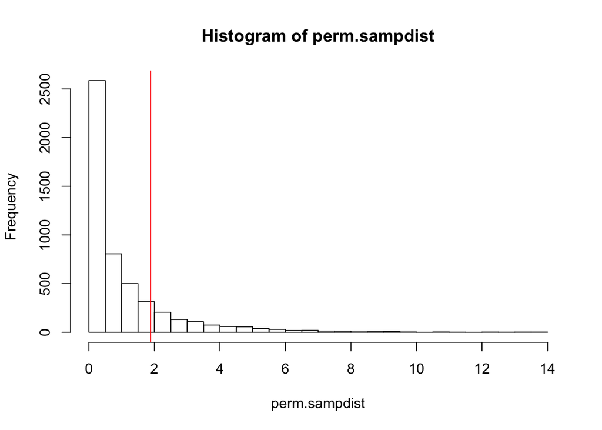

```r
hist(perm.sampdist,breaks=20); abline(v = Fstat,col='red')
```

### A Better Example

Now let’s do a real, more complicated example. Say we are interested in whether the presence of trees in the legume family affect the abundance of bird species. (See the following post for lots of cool additional information about this example: https://rpubs.com/collnell/manova).

```r
library(vegan)
library(dplyr)
library(ggplot2)

birds<-read.csv('https://raw.githubusercontent.com/collnell/lab-demo/master/bird_by_fg.csv')
head(birds)
```

```
##   DIVERSITY PLOT CA FR GR HE IN NE OM
## 1         M    3  0  0  0  0  2  0  0
## 2         M    9  0  0  2  0  6  0  4
## 3         M   12  0  0  0  0  2  0  2
## 4         M   17  0  0  0  0  7  0  4
## 5         M   20  0  0  0  0  1  0  4
## 6         M   21  0  0  3  0 14  0  7
```

For example, we can visualize two species at a time in two dimensions. The average abundances for both of these two species appear higher in polyclonal plots (blue dots) than in monoclonal plots (red dots):

```r
birds1<-birds%>%group_by(DIVERSITY)%>%select(IN,OM)%>%mutate(meanIN=mean(IN),meanOM=mean(OM))%>%ungroup()%>%mutate(GmeanIN=mean(IN),GmeanOM=mean(OM))
```

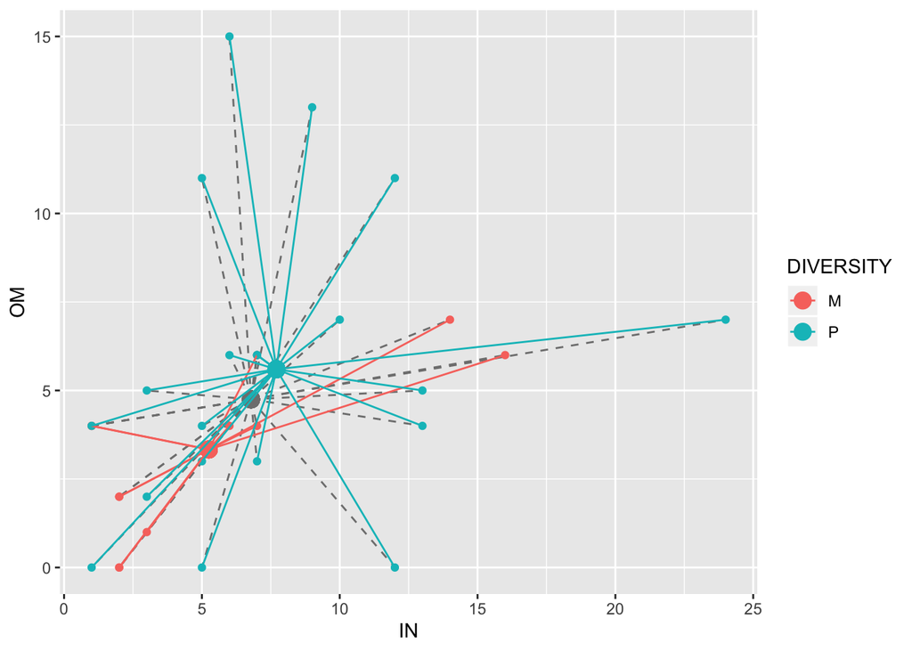

```r
ggplot(birds1,aes(IN,OM,color=DIVERSITY))+geom_point(aes(x=GmeanIN,y=GmeanOM),size=4,color="gray50")+geom_segment(aes(x=GmeanIN, y=GmeanOM, xend=IN, yend=OM),color="gray50",lty=2)+geom_point()+geom_point(aes(x=meanIN,y=meanOM),size=4)+geom_segment(aes(x=meanIN, y=meanOM, xend=IN, yend=OM))
```

But let’s test to see if this is true: are there any differences across all 7 species? We could use euclidean distances, but it is more appropriate to use an abundance-weighted distance/dissimilarity measure like Bray-Curtis. It is a good idea to take the square (or even fourth) root of the abundance counts to minimize influential observations.

```r
## WORKING
euc_dist<-vegdist(sqrt(birds[,-c(1:2)]),method="bray")
euc_distM<-vegdist(sqrt(birds[birds$DIVERSITY=="M",-c(1:2)]),method="bray")
euc_distP<-vegdist(sqrt(birds[birds$DIVERSITY=="P",-c(1:2)]),method="bray")

SSR<-sum(euc_distM^2)/12+sum(euc_distP^2)/20
SST<-sum(euc_dist^2)/32

Fstat<-(SST-SSR)/(SSR/30)

sum(euc_dist[1:12]^2)
```

```
## [1] 3.181082
```

```r
Fstat
```

```
## [1] 4.158511
```

```r
perm.sampdist<-replicate(5000,{

randbirds<-birds
randbirds$DIVERSITY<-sample(birds$DIVERSITY)

euc_dist<-vegdist(sqrt(birds[,-c(1:2)]),method="bray")
euc_distM<-vegdist(sqrt(birds[birds$DIVERSITY=="M",-c(1:2)]),method="bray")
euc_distP<-vegdist(sqrt(birds[birds$DIVERSITY=="P",-c(1:2)]),method="bray")

SSR<-sum(euc_distM^2)/12+sum(euc_distP^2)/20
SST<-sum(euc_dist^2)/32

(SST-SSR)/(SSR/30)
} )

mean(perm.sampdist>Fstat)
```

```
## [1] 0
```

```r
adonis(euc_dist~DIVERSITY,data=birds, method="bray")
```

```
##
## Call:
## adonis(formula = euc_dist ~ DIVERSITY, data = birds, method = "bray")
##
## Permutation: free
## Number of permutations: 999
##
## Terms added sequentially (first to last)
##
##           Df SumsOfSqs MeanSqs F.Model      R2 Pr(>F)
## DIVERSITY  1   0.32857 0.32857  4.1585 0.12174  0.011 *
## Residuals 30   2.37033 0.07901         0.87826
## Total     31   2.69890                 1.00000
## ---
## Signif. codes:  0 '***' 0.001 '**' 0.01 '*' 0.05 '.' 0.1 ' ' 1
```